# Coursera Data Science - Capstone Project - Milestone Report

Aled Evans

25 November 2016

## Introduction

###### This is the milestone report for the Coursera/ Johns Hopkins Data Science capstone project. The project is focused on developing a predictive text model using NLP (natural language processing) techniques. A large volume of text documents (referred to as the corpus) is analysed using NLP and to build the predictive text model. The text files used for the corpus are taken from US blogs, news and twitter – all of which are in the English language.

###### The predictive text model is similar to the models used by SwiftKey (a partner in the capstone project) in their smartphone keyboards. The predictive model takes a word (inputted by the user) and the model predicts the next word or phrase and offers it as a suggestion to the user.

###### The milestone report briefly outlines the nature of the dataset / corpus and the results of exploratory data analysis. There is also a summary of the next steps for the development of the predictive model.

#### Accessing Data and Basic Data Information

###### The data set is obtained from - https://d396qusza40orc.cloudfront.net/dsscapstone/dataset/Coursera-SwiftKey.zip

###### The code and procedures outlined below assume that the dataset is unzipped and the files are in the designated working directory of R.

###### The text files (news, blogs and twitter) are now read into R. A summary dataframe is created which outlines the size of text files; the number of words in each file; and the number of lines.

```r
# Read in news, blogs and twitter data
newsData <- readLines("en_US.news.txt", , encoding = "UTF-8", skipNul = TRUE)
blogsData <- readLines("en_US.blogs.txt", encoding = "UTF-8", skipNul = TRUE)
twitterData <- readLines("en_US.twitter.txt", encoding = "UTF-8", skipNul = TRUE)

# Obtain and print basic information on three files
library(stringi)
# File Sizes in MB's
newsDataSize <- file.info("en_US.news.txt")$size / 1024^2
blogsDataSize <- file.info("en_US.blogs.txt")$size / 1024^2
twitterDataSize <- file.info("en_US.twitter.txt")$size / 1024^2

# Number of words in each file
newsDataWords <- stri_count_words(newsData)
blogsDataWords  <- stri_count_words(blogsData)
twitterDataWords  <- stri_count_words(twitterData)

# Print table with basic summary of the three files - news, blogs and twitter
data.frame(source = c("news","blogs", "twitter"), file_size_MB = c(newsDataSize, blogsDataSize, twitterDataSize), num_lines = c(length(newsData), length(blogsData), length(twitterData)), num_words = c(sum(newsDataWords), sum(blogsDataWords), sum(twitterDataWords)))
```

```
##    source file_size_MB num_lines num_words
## 1    news     196.2775     77259   2674536
## 2   blogs     200.4242    899288  37546246
## 3 twitter     159.3641   2360148  30093410
```

## Data cleaning

###### As the files are very large, the files are sampled to give a corpus that is processed more swiftly. A 2% sample is used to construct the corpus. The corpus also undergoes text processing: all non-English characters are removed; numbers, punctuation, whitespace are also removed. Profane words are also removed. Finally, the corpus is converted to plain text.

```r
# load text mining and NLP packages
library(tm)
library(NLP)

# Create 2% of sample for Corpus
set.seed(4234)
dataSample1 <- c(sample(newsData, length(newsData) *0.02), sample(blogsData, length(blogsData) *0.02), sample(twitterData, length(twitterData) *0.02))

# remove non-English charcters from data sample using "iconv"
dataSample2 <- iconv(dataSample1, "latin1", "ASCII", sub="")

#create corpus
corpus1 <- VCorpus(VectorSource(dataSample2))

# profanity removal list - use Carnegie Mellon University's resource:  'Offensive/Profane Word List' (https://www.cs.cmu.edu/~biglou/resources/bad-words.txt)
download.file("https://www.cs.cmu.edu/~biglou/resources/bad-words.txt", destfile = "bad-words.txt")
profane_words <- read.delim("bad-words.txt", sep=":", header=FALSE)
profane_words <- profane_words[,1]

# remove additional whitespace
corpus1 <- tm_map(corpus1, stripWhitespace)
# remove numbers to create a text document
corpus1 <- tm_map(corpus1, removeNumbers)
# remove puncuation marks
corpus1 <- tm_map(corpus1, removePunctuation)
# remove profane words referenced in custom list
corpus1 <- tm_map(corpus1, removeWords, profane_words)
# transform to plain text document
corpus1 <- tm_map(corpus1, PlainTextDocument)
```

## Exploratory Data Analysis

#### Tokenize and find n-gram frequency

###### The RWeka package is used to create functions that tokenize the corpus and find n-grams. The tokenization is for finding the frequency of three types of n-gram: unigrams (single words), bigrams (two word phrases) and trigrams (three word phrases).

###### The n-grams indicate which words appear together in the text. The higher the frequency of a certain n-gram, the more likely it is to be found in the corpus. The use of n-gram frequency is key to building this form of predictive text model.

```r
library(ggplot2)
library(RWeka)

# Tokenizer function  for n-grams.
# Unigram tokenizer - 1 word
unigramToken <- function(x) NGramTokenizer(x, Weka_control(min=1, max=1))
# Bigram tokenizer - 2 words
bigramToken <- function(x) NGramTokenizer(x, Weka_control(min=2, max=2))
# Trigram tokenizer - 3 words
trigramToken <- function(x) NGramTokenizer(x, Weka_control(min=3, max=3))

options(mc.cores = 1)
# helper function to find frequency of n-grams in the corpus
topFreq <- function(tdm) {
    freq <- sort(rowSums(as.matrix(tdm)), decreasing = TRUE)
    freq_dataframe <- (data.frame(word = names(freq), freq = freq))
    return(freq_dataframe)
}

# Create files with n-gram frequency - most common unigrams, bigrams and trigrams - for plotting.
# Unigram frequency
unigram_freq <- TermDocumentMatrix(corpus1, control=list(tokenize=unigramToken))
unigram_freq2 <- removeSparseTerms(unigram_freq, 0.99)
uniCorpus_freq3 <- topFreq(unigram_freq2)

# bigram frequency
bigram_freq <- TermDocumentMatrix(corpus1, control=list(tokenize=bigramToken ))
bigram_freq2 <- removeSparseTerms(bigram_freq, 0.999)
biCorpus_freq3 <- topFreq(bigram_freq2)

# trigram frequency
trigram_freq <- TermDocumentMatrix(corpus1,  control=list(tokenize=trigramToken))
trigram_freq2 <- removeSparseTerms(trigram_freq, 0.9999)
triCorpus_freq3 <- topFreq(trigram_freq2)
```

## Data Visualization

###### The plot of the top 20 (i.e. most frequent) unigrams:

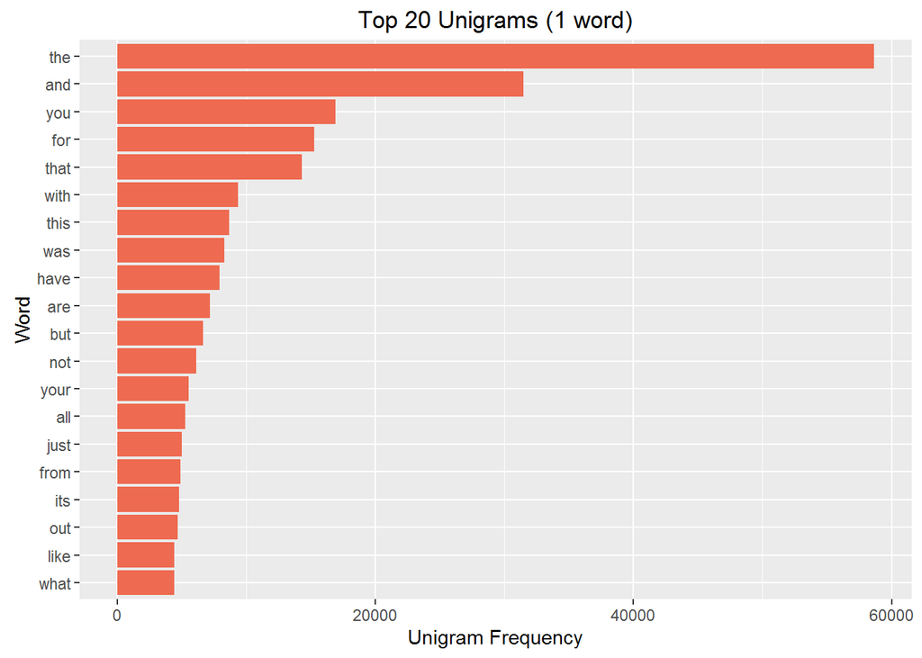

```r
# plot top 20 unigrams
n_gram_chart <- ggplot(uniCorpus_freq3[1:20,], aes(x=reorder(word, freq), y =freq)) +
       theme(legend.title = element_blank()) +
        geom_bar(stat="identity", fill = "coral2") + coord_flip() + labs(title= "Top 20 Unigrams (1 word)") +
    xlab("Word") +
    ylab("Unigram Frequency")
print(n_gram_chart)
```

###### A plot of the top 20 bigrams:

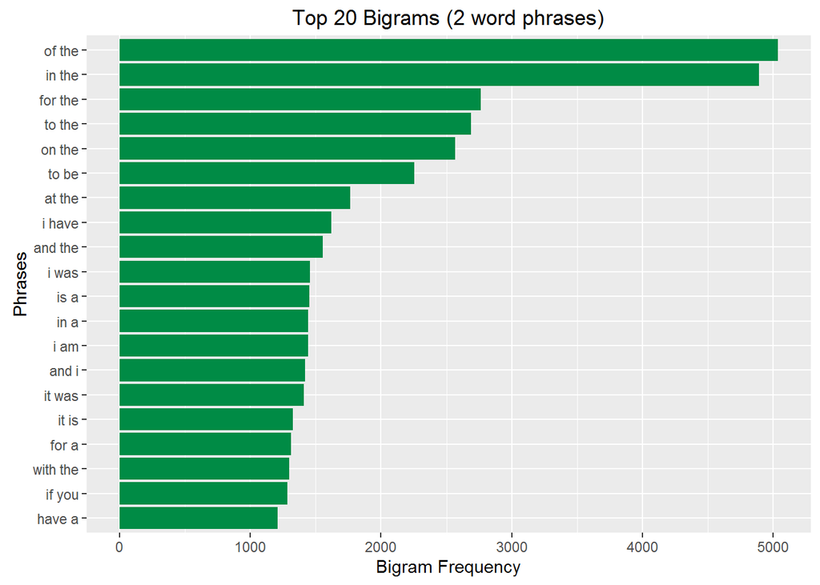

```r
# plot top 20 bigrams
bi_gram_chart <- ggplot(biCorpus_freq3[1:20,], aes(x=reorder(word, freq), y =freq)) +
       theme(legend.title = element_blank()) +
        geom_bar(stat="identity", fill = "springgreen4") + coord_flip() + labs(title= "Top 20 Bigrams (2 word phrases)") +
    xlab("Phrases") +
    ylab("Bigram Frequency")
print(bi_gram_chart)
```

###### A plot of the top 20 trigrams:

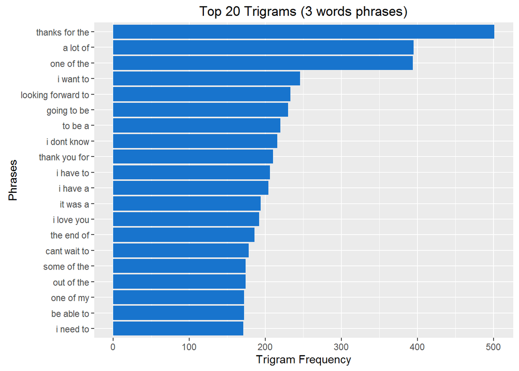

```r
# plot top 20 trigrams
tri_gram_chart <- ggplot(triCorpus_freq3[1:20,], aes(x=reorder(word, freq), y =freq)) +
       theme(legend.title = element_blank()) +
        geom_bar(stat="identity", fill = "dodgerblue3") + coord_flip() + labs(title= "Top 20 Trigrams (3 words phrases)") +
    xlab("Phrases") +
    ylab("Trigram Frequency")
print(tri_gram_chart)
```

## Next steps for project

###### The exploratory data analysis has demonstrated the occurrence of a range of n-grams that can be used to build a predictive text model. One possible strategy is for the predictive model, once the user has entered a word, to first use a trigram to predict the next word. If the trigram does not provide a match, a bigram is then used to predict the next word. This is a version of a ‘back-off model’ (reference: https://en.wikipedia.org/wiki/Katz's_back-off_model)

###### Once the predictive model is developed, it will use a Shiny app as the user interface. The Shiny app will suggest the next word for a user based on the initial text input of the user.